# Quantitative Analysis

Matt Clark

11/29/2019

# Introduction

R was initially built for analyzing quantitative data. It is still considered by many people to be the premier platform for scientific analysis. Analysis may seem a bit scary, but we will see that it’s actually quite easy.

In this lesson, we will go over.

1. Simple T-tests
2. ANOVAS
3. Single variable linear models
4. Multivariat linear models
5. Hierarchical linear models
6. Uing model objects to predict things and validate models.

# Learning Objectives

- LO1
- LO2
- LO3
- LO4
- LO6

# Content

First let’s load the pakages we will use during this lesson

```r
library(tidyverse)
library(lme4)
```

Now let’s load the data Keep in mind that your file path will likely be different than the file path shown below

```r
dat<-read_csv("~/Kinesiology_Teaching/Data/Manuscript_Data.csv")
```

Let’s change the Sex variable to be more represintitive of how we actually think of ‘Sex’ data.

```r
dat$Sex<-as.character(dat$Sex)

#now change the vector
dat$Sex<-dplyr::recode(dat$Sex, "1" = "Male", "2" = "Female", .default = NA_character_)
```

Ok, lets also rename some of the quantitative variables in our dataframe so that they are easier to deal with

```r
names(dat)[52]<-"Variable_1"
names(dat)[65]<-"Variable_2"
names(dat)[75]<-"Variable_3"
names(dat)[100]<-"Variable_4"
```

Let’s get rid of the variables we aren’t going to use.

There are many ways to do this, here’s two (one is commented out):

```r
#dat<-dat%>%select(Subject, Sex, Variable_1,Variable_2,Variable_3,Variable_4)
dat<-dat[,c(1,2,52,65,75,100)]
head(dat)
```

```
## # A tibble: 6 x 6
##   Subject Sex    Variable_1 Variable_2 Variable_3 Variable_4
##     <dbl> <chr>       <dbl>      <dbl>      <dbl>      <dbl>
## 1       7 Female       43.5       7.53       35.2       48.5
## 2       8 Male         29.0      12.2        35.2       31.9
## 3       9 Female       51.4      29.6        29.8       56.9
## 4      10 Male         56.9      11.6        32.8       46.9
## 5      11 Male         32.8      15.5        34.1       44.2
## 6      12 Male         30.1      19.6        46.8       47.7
```

We want to see some statistical significance in our analyses. Let’s order `Variable_1`, then create a dummy `Treatment` variable that will hopefully look significant.

```r
dat<-arrange(dat, Variable_1)
```

Now let’s add the treatment category

```r
dat$Treatment<-c(rep("A",12),rep("B",12),rep("C",12))
```

Ok, now we should have a treatment variable that may be reflective of increasing `Variable_1`

###T-tests Let’s compare two things using a t-test

Lets compare treatment A to treatment c

```r
x<-dat%>%filter(Treatment=="A")
y<-dat%>%filter(Treatment=="C")
```

Now that we have two different dataframes, let’s compare them with a T-test

```r
t.test(x$Variable_1, y$Variable_1)
```

```
##
##  Welch Two Sample t-test
##
## data:  x$Variable_1 and y$Variable_1
## t = -10.797, df = 20.739, p-value = 5.724e-10
## alternative hypothesis: true difference in means is not equal to 0
## 95 percent confidence interval:
##  -22.30717 -15.09729
## sample estimates:
## mean of x mean of y
##  36.54730  55.24953
```

we see here that our p value is very low 5.724e-10, So they are significantly different.

###ANOVAS Now, what if we wanted to compare all three treatments (A,B,C)

It’s always a good isea to plot your data before analyzing it

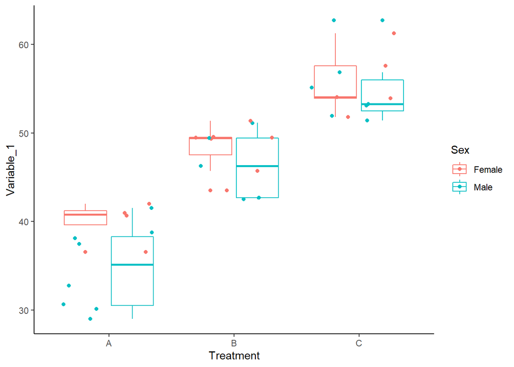

```r
ggplot(dat, aes(x=Treatment, y=Variable_1, color=Sex))+
  geom_boxplot()+
  geom_jitter()+
  theme_classic()
```

It looks like treatment makes a big difference here. Let’s run an ANOVA to compare 3+ groups

```r
fit <- aov(Variable_1 ~ Treatment, data=dat)
summary(fit)
```

```
##             Df Sum Sq Mean Sq F value   Pr(>F)
## Treatment    2 2120.1  1060.0   68.41 1.82e-12 ***
## Residuals   33  511.4    15.5
## ---
## Signif. codes:  0 '***' 0.001 '**' 0.01 '*' 0.05 '.' 0.1 ' ' 1
```

Cool…The group’s aren’t alll the same…We probably already knew that.

There’s a phrase that I like that says.

“If there’s a real difference, you don’t need statistics..this is a good example.”

What we *can* do though is use a linear model to tell us exactly what the difference is quantitatively.

### Linear models

Let’s look at the effect that `Treatment` has on `Variable_1`.

```r
fit <- lm(Variable_1 ~ Treatment, data=dat)
summary(fit)
```

```
##
## Call:
## lm(formula = Variable_1 ~ Treatment, data = dat)
##
## Residuals:
##     Min      1Q  Median      3Q     Max
## -7.5593 -3.3471  0.4744  2.2321  7.4651
##
## Coefficients:
##             Estimate Std. Error t value Pr(>|t|)
## (Intercept)   36.547      1.136  32.162  < 2e-16 ***
## TreatmentB    10.988      1.607   6.837 8.40e-08 ***
## TreatmentC    18.702      1.607  11.638 3.19e-13 ***
## ---
## Signif. codes:  0 '***' 0.001 '**' 0.01 '*' 0.05 '.' 0.1 ' ' 1
##
## Residual standard error: 3.936 on 33 degrees of freedom
## Multiple R-squared:  0.8057, Adjusted R-squared:  0.7939
## F-statistic: 68.41 on 2 and 33 DF,  p-value: 1.823e-12
```

The `lm()` function has a built in `plot()` capability that some people think is useful.

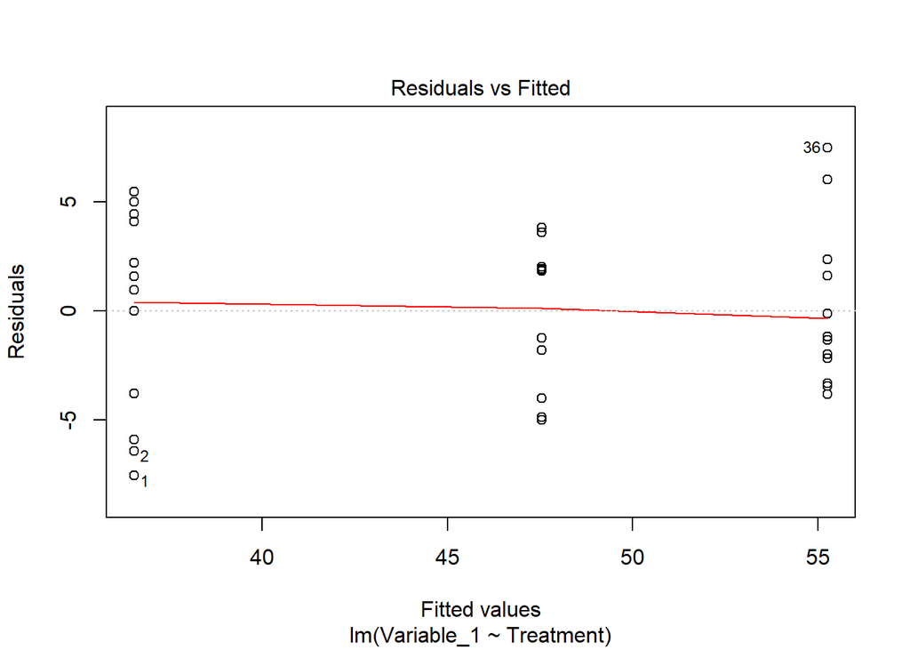

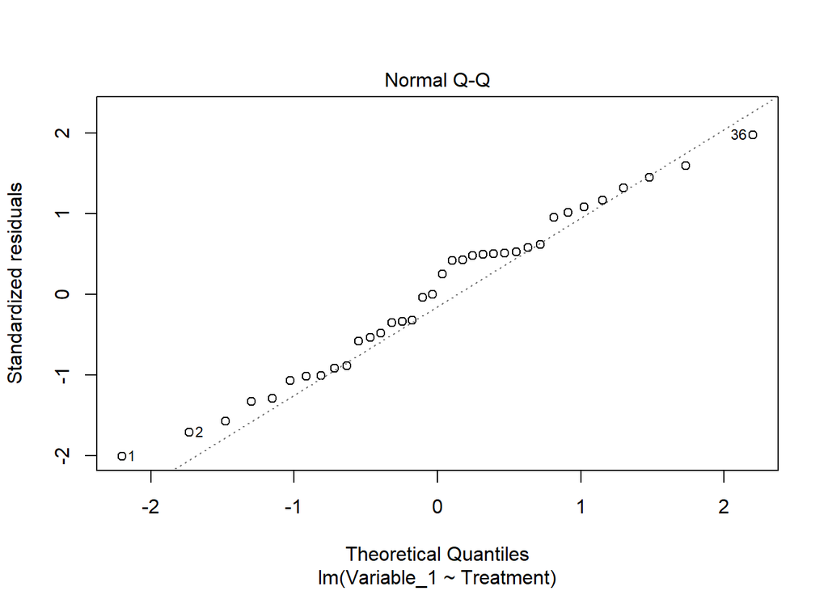

```
## hat values (leverages) are all = 0.08333333
##  and there are no factor predictors; no plot no. 5
```

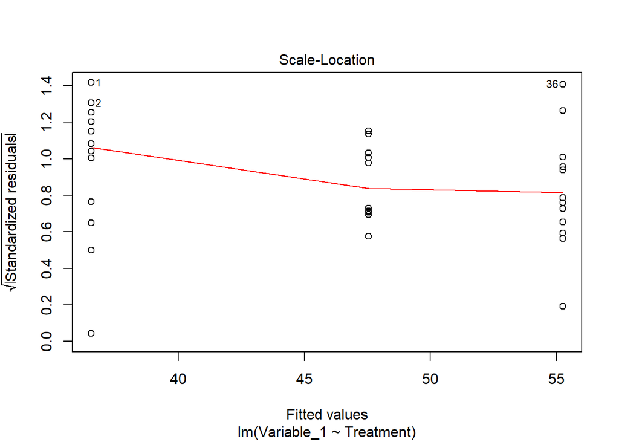

```r
plot(fit)
```

Let’s also look at our residuals, these should be relatively normal.

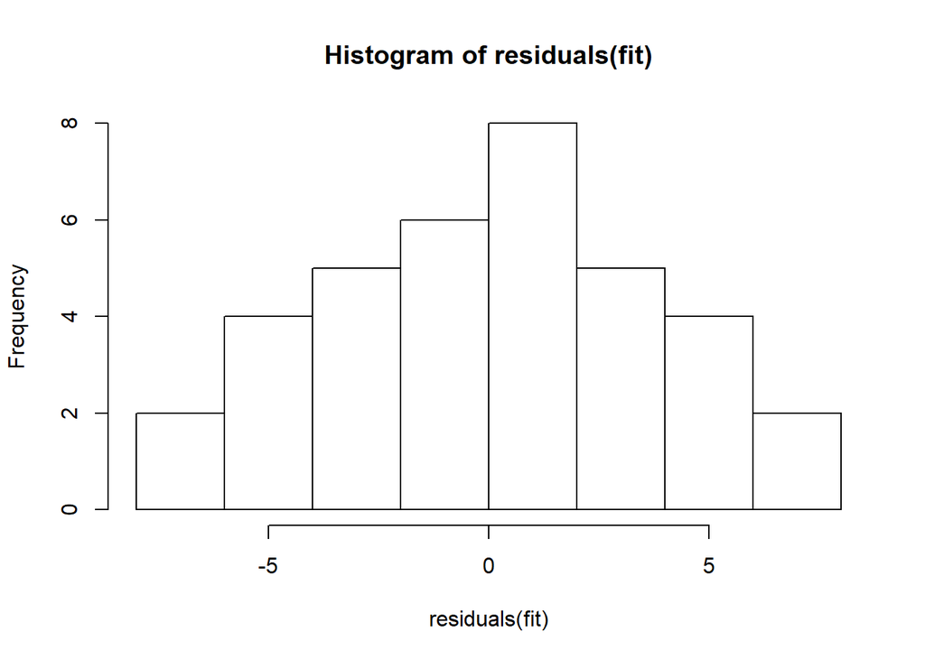

```r
hist(residuals(fit))
```

How do we interpret our model results?

Let’s look at `summary()` again

```r
fit<-lm(Variable_1~Treatment, data=dat)
summary(fit)
```

```
##
## Call:
## lm(formula = Variable_1 ~ Treatment, data = dat)
##
## Residuals:
##     Min      1Q  Median      3Q     Max
## -7.5593 -3.3471  0.4744  2.2321  7.4651
##
## Coefficients:
##             Estimate Std. Error t value Pr(>|t|)
## (Intercept)   36.547      1.136  32.162  < 2e-16 ***
## TreatmentB    10.988      1.607   6.837 8.40e-08 ***
## TreatmentC    18.702      1.607  11.638 3.19e-13 ***
## ---
## Signif. codes:  0 '***' 0.001 '**' 0.01 '*' 0.05 '.' 0.1 ' ' 1
##
## Residual standard error: 3.936 on 33 degrees of freedom
## Multiple R-squared:  0.8057, Adjusted R-squared:  0.7939
## F-statistic: 68.41 on 2 and 33 DF,  p-value: 1.823e-12
```

Why are there only two treatments displayed?

Treatment_A is the intercept!

Summary gives us some parameter estimates. What do these mean?

Let’s check out the means to get a better idea

```r
mean(dat[dat$Treatment=="A",]$Variable_1)
```

```
## [1] 36.5473
```

```r
mean(dat[dat$Treatment=="B",]$Variable_1)
```

```
## [1] 47.53512
```

```r
mean(dat[dat$Treatment=="C",]$Variable_1)
```

```
## [1] 55.24953
```

The parameter estimate (for a standard linear model) tells us how much the dependant variable increases as a result of the independant variables.

Compare the means from above to the parameter estimates from the model. How are they the same, how are they different?

What about continuous by continuous. Let’s plot it.

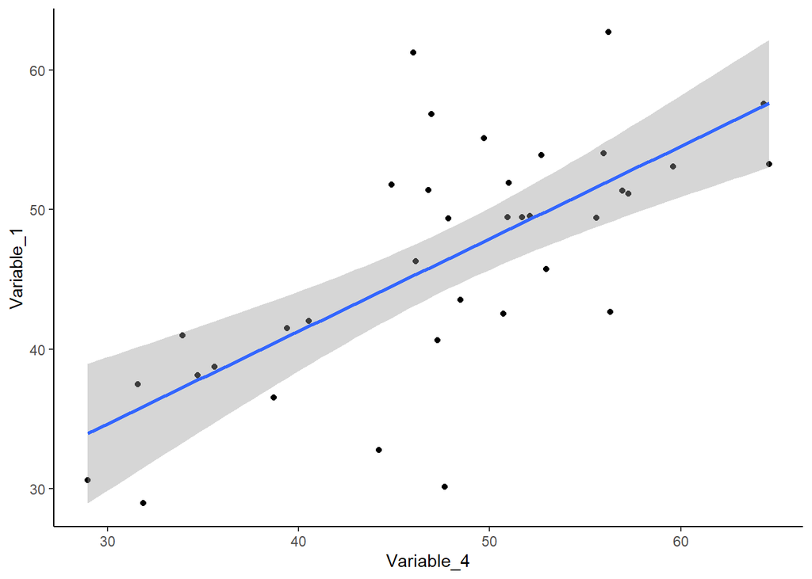

```r
ggplot(dat, aes(x=Variable_4, y=Variable_1))+
  geom_point()+
  geom_smooth(method="lm")+
  theme_classic()
```

Let’s model what we just saw

```r
fit <- lm(Variable_1 ~ Variable_4, data=dat)
summary(fit)
```

```
##
## Call:
## lm(formula = Variable_1 ~ Variable_4, data = dat)
##
## Residuals:
##      Min       1Q   Median       3Q      Max
## -16.2336  -3.5028   0.3521   2.9817  15.9905
##
## Coefficients:
##             Estimate Std. Error t value Pr(>|t|)
## (Intercept)  14.7566     5.7506   2.566   0.0149 *
## Variable_4    0.6632     0.1183   5.606  2.8e-06 ***
## ---
## Signif. codes:  0 '***' 0.001 '**' 0.01 '*' 0.05 '.' 0.1 ' ' 1
##
## Residual standard error: 6.342 on 34 degrees of freedom
## Multiple R-squared:  0.4803, Adjusted R-squared:  0.465
## F-statistic: 31.43 on 1 and 34 DF,  p-value: 2.802e-06
```

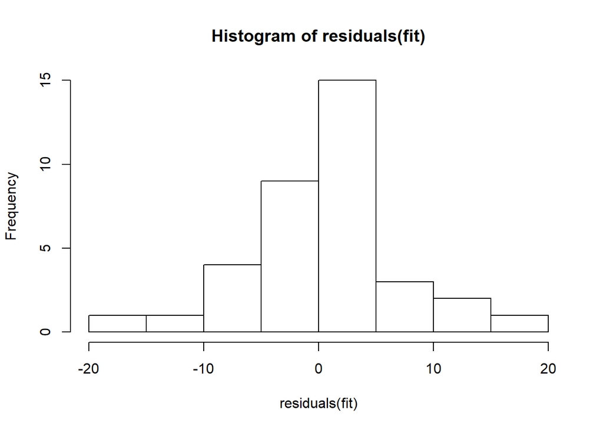

```r
hist(residuals(fit))
```

###Multivariate regression We can look at multivariable regressions too

Let’s look at all of our continuous variables as a predictor for Variable_1.

```r
fit<-lm(Variable_1~Variable_4+Variable_3+Variable_2+Treatment, data=dat)
summary(fit)
```

```
##
## Call:
## lm(formula = Variable_1 ~ Variable_4 + Variable_3 + Variable_2 +
##     Treatment, data = dat)
##
## Residuals:
##     Min      1Q  Median      3Q     Max
## -6.8312 -3.2235  0.4054  2.5680  7.5444
##
## Coefficients:
##             Estimate Std. Error t value Pr(>|t|)
## (Intercept) 36.45726    6.22756   5.854 2.10e-06 ***
## Variable_4   0.10652    0.12645   0.842 0.406257
## Variable_3  -0.10610    0.13695  -0.775 0.444557
## Variable_2  -0.02414    0.10044  -0.240 0.811717
## TreatmentB   9.31965    2.47048   3.772 0.000711 ***
## TreatmentC  16.63040    2.65675   6.260 6.76e-07 ***
## ---
## Signif. codes:  0 '***' 0.001 '**' 0.01 '*' 0.05 '.' 0.1 ' ' 1
##
## Residual standard error: 4.037 on 30 degrees of freedom
## Multiple R-squared:  0.8142, Adjusted R-squared:  0.7832
## F-statistic: 26.29 on 5 and 30 DF,  p-value: 4.018e-10
```

Note that variable 2 has the highest p value remove that first.

```r
fit<-lm(Variable_1~Variable_4+Variable_3+Treatment, data=dat)
summary(fit)
```

```
##
## Call:
## lm(formula = Variable_1 ~ Variable_4 + Variable_3 + Treatment,
##     data = dat)
##
## Residuals:
##    Min     1Q Median     3Q    Max
## -6.791 -3.289  0.399  2.544  7.526
##
## Coefficients:
##             Estimate Std. Error t value Pr(>|t|)
## (Intercept) 36.73930    6.02231   6.101 9.22e-07 ***
## Variable_4   0.09897    0.12061   0.821 0.418172
## Variable_3  -0.11675    0.12759  -0.915 0.367222
## TreatmentB   9.42803    2.39177   3.942 0.000429 ***
## TreatmentC  16.78712    2.53603   6.619 2.13e-07 ***
## ---
## Signif. codes:  0 '***' 0.001 '**' 0.01 '*' 0.05 '.' 0.1 ' ' 1
##
## Residual standard error: 3.975 on 31 degrees of freedom
## Multiple R-squared:  0.8138, Adjusted R-squared:  0.7898
## F-statistic: 33.88 on 4 and 31 DF,  p-value: 6.571e-11
```

```r
fit<-lm(Variable_1~Variable_4+Treatment, data=dat)
summary(fit)
```

```
##
## Call:
## lm(formula = Variable_1 ~ Variable_4 + Treatment, data = dat)
##
## Residuals:
##     Min      1Q  Median      3Q     Max
## -7.2672 -3.0126  0.7698  2.2437  7.2071
##
## Coefficients:
##             Estimate Std. Error t value Pr(>|t|)
## (Intercept) 33.27228    4.66922   7.126 4.37e-08 ***
## Variable_4   0.08648    0.11953   0.723 0.474638
## TreatmentB   9.74482    2.36056   4.128 0.000244 ***
## TreatmentC  17.37438    2.44724   7.100 4.70e-08 ***
## ---
## Signif. codes:  0 '***' 0.001 '**' 0.01 '*' 0.05 '.' 0.1 ' ' 1
##
## Residual standard error: 3.965 on 32 degrees of freedom
## Multiple R-squared:  0.8088, Adjusted R-squared:  0.7909
## F-statistic: 45.12 on 3 and 32 DF,  p-value: 1.334e-11
```

We see now that none of our continuous variables are important when we account for Treatment

They are whe we only usse Variable_4 though..This is a good lesson in model selection!

Now control for sex. You can make a 3d plot or a density plot to plot 2 variable regressions.

We’re not going to show these.

Let’s do the same type of multivariate regression as before.

```r
fit<-lm(Variable_1~Sex+Treatment, data=dat)
summary(fit)
```

```
##
## Call:
## lm(formula = Variable_1 ~ Sex + Treatment, data = dat)
##
## Residuals:
##     Min      1Q  Median      3Q     Max
## -6.6966 -2.8492  0.7807  2.6856  8.5435
##
## Coefficients:
##             Estimate Std. Error t value Pr(>|t|)
## (Intercept)   38.273      1.388  27.579  < 2e-16 ***
## SexMale       -2.588      1.293  -2.002   0.0538 .
## TreatmentB    10.341      1.572   6.578 2.06e-07 ***
## TreatmentC    18.487      1.542  11.987 2.26e-13 ***
## ---
## Signif. codes:  0 '***' 0.001 '**' 0.01 '*' 0.05 '.' 0.1 ' ' 1
##
## Residual standard error: 3.768 on 32 degrees of freedom
## Multiple R-squared:  0.8273, Adjusted R-squared:  0.8111
## F-statistic:  51.1 on 3 and 32 DF,  p-value: 2.644e-12
```

A better way to do this is to give each sex its own intercept, slope, or both. These will both be more representitive of reality.

Let’s plot both

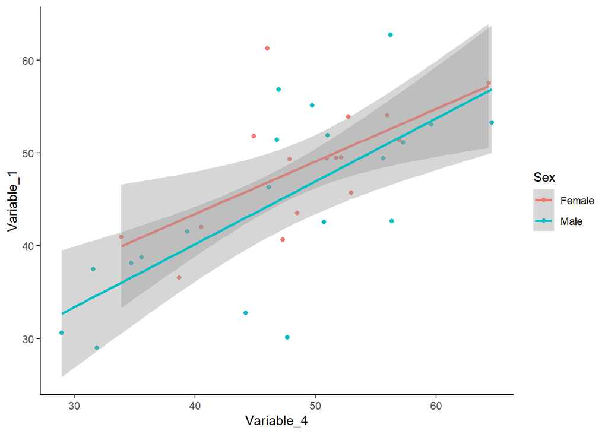

```r
ggplot(dat, aes(x=Variable_4, y=Variable_1, color=Sex))+
  geom_point()+
  geom_smooth(method="lm")+
  theme_classic()
```

We need a new package to fit this model.

```r
fit <- lmer(Variable_1 ~ Variable_4+(Variable_4|Sex), data=dat)
```

```
## boundary (singular) fit: see ?isSingular
```

```r
summary(fit)
```

```
## Linear mixed model fit by REML ['lmerMod']
## Formula: Variable_1 ~ Variable_4 + (Variable_4 | Sex)
##    Data: dat
##
## REML criterion at convergence: 233.6
##
## Scaled residuals:
##      Min       1Q   Median       3Q      Max
## -2.53982 -0.59301  0.02442  0.44377  2.48968
##
## Random effects:
##  Groups   Name        Variance  Std.Dev. Corr
##  Sex      (Intercept) 2.007e+00 1.41671
##           Variable_4  2.374e-04 0.01541  -1.00
##  Residual             3.996e+01 6.32125
## Number of obs: 36, groups:  Sex, 2
##
## Fixed effects:
##             Estimate Std. Error t value
## (Intercept)  15.0182     5.8450   2.569
## Variable_4    0.6583     0.1189   5.538
##
## Correlation of Fixed Effects:
##            (Intr)
## Variable_4 -0.980
## convergence code: 0
## boundary (singular) fit: see ?isSingular
```

If we wanted each sex to just have its own intercept.

```r
fit <- lmer(Variable_1 ~ Variable_4+(1|Sex), data=dat)
summary(fit)
```

```
## Linear mixed model fit by REML ['lmerMod']
## Formula: Variable_1 ~ Variable_4 + (1 | Sex)
##    Data: dat
##
## REML criterion at convergence: 233.6
##
## Scaled residuals:
##     Min      1Q  Median      3Q     Max
## -2.5416 -0.5857  0.0297  0.4533  2.4962
##
## Random effects:
##  Groups   Name        Variance Std.Dev.
##  Sex      (Intercept)  0.4124  0.6421
##  Residual             40.0085  6.3252
## Number of obs: 36, groups:  Sex, 2
##
## Fixed effects:
##             Estimate Std. Error t value
## (Intercept)  14.8987     5.7631   2.585
## Variable_4    0.6606     0.1181   5.592
##
## Correlation of Fixed Effects:
##            (Intr)
## Variable_4 -0.980
```

[Here is a great resource explaining heierarchical modeling.](http://mfviz.com/hierarchical-models/)

### Predictions and model validation

Making predictions is a really powerful. We like to be able to predict things, but also to gutcheck yourself!

Make a new dataframe with some hypothetical values to put into the model

```r
new <- data.frame(Variable_4 = 25, Treatment="B", Sex="Male")
```

Now put it into a predict function

```r
predict(fit, new)
```

```
##        1
## 31.23722
```